# Analysis of the ToothGrowth data

Jae Wook Lee

October 24, 2015

The ToothGrowth data is loaded and summarized by the following code.

```r
data(ToothGrowth)
summary(ToothGrowth)
```

```
##       len        supp         dose
##  Min.   : 4.20   OJ:30   Min.   :0.500
##  1st Qu.:13.07   VC:30   1st Qu.:0.500
##  Median :19.25           Median :1.000
##  Mean   :18.81           Mean   :1.167
##  3rd Qu.:25.27           3rd Qu.:2.000
##  Max.   :33.90           Max.   :2.000
```

The scatterplot and boxplot show that there seems to be a significant difference in tooth length between OJ and VC groups for doses 0.5 and 1.0. In addition, the line graph below shows that there is an increase in tooth length as dose increases from 0.5 to 2.0.

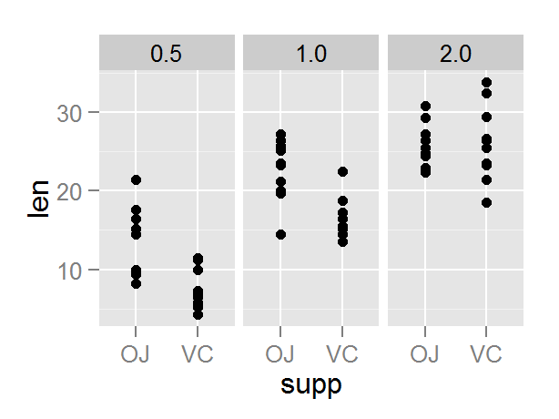

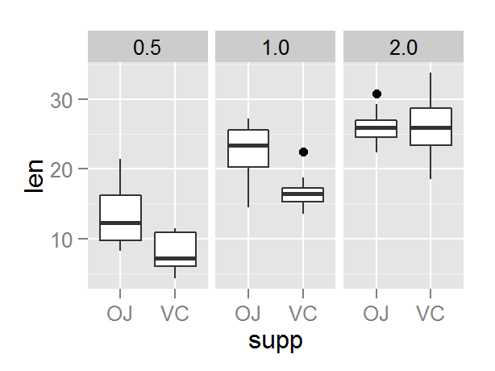

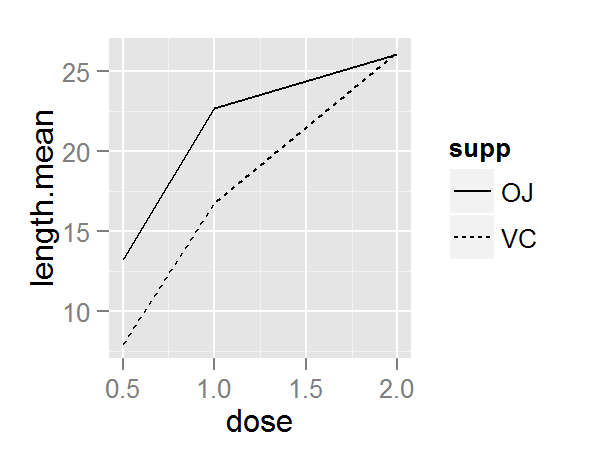

```r
# a function that returns the confidence interval, t statistic, and p value for the difference of means between two vectors
tt <- function(v1, v2) {
        diffmean <- mean(v1) - mean(v2)   # difference in means
        se <- sqrt(var(v1)/length(v1) + var(v2)/length(v2))   # standard error for t-statistic
        conf.int <- diffmean + c(-1,1)*qt(0.975, length(v1) + length(v2) -2)*se  # confidence interval
        t <- diffmean / se
        p <- pt(t, length(v1) + length(v2) -2, lower.tail=FALSE)
        vec <- round(c(conf.int, t, p),5)
        names(vec) <- c("Conf.int.lower.limit","Conf.int.upper.limit","t","p-value")
        return(vec)
}
```

For dose 0.5,

```
## Conf.int.lower.limit Conf.int.upper.limit                    t
##              1.77026              8.72974              3.16973
##              p-value
##              0.00265
```

The 95% confidence interval for mean difference between VJ and OC does not contain zero, and p-value is below 0.05. Therefore, the null hypothesis is rejected and the conclusion is that there is a significant difference in tooth length between VJ and OC at dose 0.5.

For dose 1.0,

```
## Conf.int.lower.limit Conf.int.upper.limit                    t
##              2.84069              9.01931              4.03277
##              p-value
##              0.00039
```

The 95% confidence interval for mean difference between VJ and OC does not contain zero, and p-value is below 0.05. Therefore, the null hypothesis is rejected and the conclusion is that there is a significant difference in tooth length between VJ and OC at dose 1.0.

For dose 2.0,

```
## Conf.int.lower.limit Conf.int.upper.limit                    t
##             -3.72300              3.56300             -0.04614
##              p-value
##              0.51815
```